# R Notebook

# Load in libraries

```r
library(tidyverse)
library(here)
library(janitor)
library(tsibble)
library(lubridate)
library(sf)
```

# Load in data sets

```r
waiting_times_raw <- read_csv(here("raw_data/non_covid/monthly_ae_waitingtimes_202206.csv")) %>%
  clean_names()
hb <- read_csv(here("raw_data/general/hb14_hb19.csv")) %>%
  clean_names() %>%
  select(hb, hb_name)
hospitals <- read_csv(here("raw_data/general/current-hospital_flagged20211216.csv")) %>%
  clean_names() %>%
  select(location, location_name)
```

# clean dataset

The following cleaning does the following to the waiting times data set: - converts month column to year_month dates and extracts years and months  
- joins health board and hospital names to data set  
- renames columns to more easily understandable names  
- removes columns relating to “episodes”, “qualifier codes” and “discharges” - adds new value of wait greater than 4 hours to the data  
- *replaces all NA values with 0 (this step may be optional)*

Please note that 4 hours wait time is the “Target” wait time for the NHS and is represented by the “wait_lt_4hrs” column values.

```r
# cleaning script
waiting_times <- waiting_times_raw %>%
  mutate(date_ym = ym(month), .before = month,
         month = month(date_ym, label = TRUE, abbr = FALSE),
         year = year(date_ym)) %>%
  left_join(hb, c("hbt" = "hb")) %>%
  left_join(hospitals, c("treatment_location" = "location")) %>%
  rename(total_attendance = number_of_attendances_aggregate,
         wait_lt_4hrs = number_meeting_target_aggregate,
         wait_gt_8hrs = attendance_greater8hrs,
         wait_gt_12hrs = attendance_greater12hrs,
         health_board = hb_name,
         hospital_id = treatment_location,
         hospital_name = location_name) %>%
  select(date_ym, year, month, health_board, hospital_id, hospital_name, department_type,
         total_attendance, wait_lt_4hrs, wait_gt_8hrs, wait_gt_12hrs) %>%
  mutate(wait_gt_4hrs = total_attendance - wait_lt_4hrs, .after = wait_lt_4hrs) %>%
  mutate(across(total_attendance:wait_gt_12hrs, .fns = ~coalesce(., 0)))

waiting_times
```

| date_ym | year | month | health_board | hospital_id | hospital_name | department_type | total_attendance | wait_lt_4hrs | wait_gt_4hrs | wait_gt_8hrs | wait_gt_12hrs |
| --- | --- | --- | --- | --- | --- | --- | --- | --- | --- | --- | --- |
| 2007-07-01 | 2007 | July | NHS Ayrshire and Arran | A101H | Arran War Memorial Hospital | Minor Injury Unit or Other | 252 | 252 | 0 | 0 | 0 |
| 2007-07-01 | 2007 | July | NHS Ayrshire and Arran | A111H | University Hospital Crosshouse | Emergency Department | 5414 | 5290 | 124 | 26 | 24 |
| 2007-07-01 | 2007 | July | NHS Ayrshire and Arran | A207H | NA | Minor Injury Unit or Other | 92 | 92 | 0 | 0 | 0 |
| 2007-07-01 | 2007 | July | NHS Ayrshire and Arran | A210H | University Hospital Ayr | Emergency Department | 3530 | 3355 | 175 | 3 | 1 |
| 2007-07-01 | 2007 | July | NHS Borders | B103H | The Knoll Hospital | Minor Injury Unit or Other | 20 | 20 | 0 | 0 | 0 |
| 2007-07-01 | 2007 | July | NHS Borders | B105H | Hawick Community Hospital | Minor Injury Unit or Other | 105 | 105 | 0 | 0 | 0 |
| 2007-07-01 | 2007 | July | NHS Borders | B114H | Kelso Hospital | Minor Injury Unit or Other | 31 | 31 | 0 | 0 | 0 |
| 2007-07-01 | 2007 | July | NHS Borders | B118H | Hay Lodge Hospital | Minor Injury Unit or Other | 87 | 87 | 0 | 0 | 0 |
| 2007-07-01 | 2007 | July | NHS Borders | B120H | Borders General Hospital | Emergency Department | 1823 | 1804 | 19 | 0 | 0 |
| 2007-07-01 | 2007 | July | NHS Dumfries and Galloway | Y101H | Castle Douglas Community Hospital | Minor Injury Unit or Other | 86 | 86 | 0 | 0 | 0 |

[output cut: 990 more lines]

```r
# create table with proportions of wait times used for the analysis
waiting_times_prop <- waiting_times %>%
  pivot_longer(contains("wait"), names_to = "wait_category", values_to = "number_of_attendances") %>%
  mutate(wait_prop = number_of_attendances / total_attendance,
         wait_category = str_replace(wait_category, "wait", "prop")) %>%
  select(-number_of_attendances) %>%
  pivot_wider(names_from = wait_category, values_from = wait_prop)


waiting_times_prop
```

| date_ym | year | month | health_board | hospital_id | hospital_name | department_type | total_attendance | prop_lt_4hrs | prop_gt_4hrs | prop_gt_8hrs | prop_gt_12hrs |
| --- | --- | --- | --- | --- | --- | --- | --- | --- | --- | --- | --- |
| 2007-07-01 | 2007 | July | NHS Ayrshire and Arran | A101H | Arran War Memorial Hospital | Minor Injury Unit or Other | 252 | 1.0000000 | 0.0000000000 | 0.0000000000 | 0.0000000000 |
| 2007-07-01 | 2007 | July | NHS Ayrshire and Arran | A111H | University Hospital Crosshouse | Emergency Department | 5414 | 0.9770964 | 0.0229035833 | 0.0048023642 | 0.0044329516 |
| 2007-07-01 | 2007 | July | NHS Ayrshire and Arran | A207H | NA | Minor Injury Unit or Other | 92 | 1.0000000 | 0.0000000000 | 0.0000000000 | 0.0000000000 |
| 2007-07-01 | 2007 | July | NHS Ayrshire and Arran | A210H | University Hospital Ayr | Emergency Department | 3530 | 0.9504249 | 0.0495750708 | 0.0008498584 | 0.0002832861 |
| 2007-07-01 | 2007 | July | NHS Borders | B103H | The Knoll Hospital | Minor Injury Unit or Other | 20 | 1.0000000 | 0.0000000000 | 0.0000000000 | 0.0000000000 |
| 2007-07-01 | 2007 | July | NHS Borders | B105H | Hawick Community Hospital | Minor Injury Unit or Other | 105 | 1.0000000 | 0.0000000000 | 0.0000000000 | 0.0000000000 |
| 2007-07-01 | 2007 | July | NHS Borders | B114H | Kelso Hospital | Minor Injury Unit or Other | 31 | 1.0000000 | 0.0000000000 | 0.0000000000 | 0.0000000000 |
| 2007-07-01 | 2007 | July | NHS Borders | B118H | Hay Lodge Hospital | Minor Injury Unit or Other | 87 | 1.0000000 | 0.0000000000 | 0.0000000000 | 0.0000000000 |
| 2007-07-01 | 2007 | July | NHS Borders | B120H | Borders General Hospital | Emergency Department | 1823 | 0.9895776 | 0.0104223807 | 0.0000000000 | 0.0000000000 |
| 2007-07-01 | 2007 | July | NHS Dumfries and Galloway | Y101H | Castle Douglas Community Hospital | Minor Injury Unit or Other | 86 | 1.0000000 | 0.0000000000 | 0.0000000000 | 0.0000000000 |

[output cut: 990 more lines]

# Analysis

## How does hospital attendances change with time?

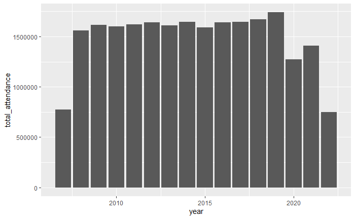

```r
# plot all data - attendances per year
waiting_times %>%
  group_by(year) %>%
  summarise(total_attendance = sum(total_attendance)) %>%
  ggplot(aes(x = year, y = total_attendance)) +
  geom_col()
```

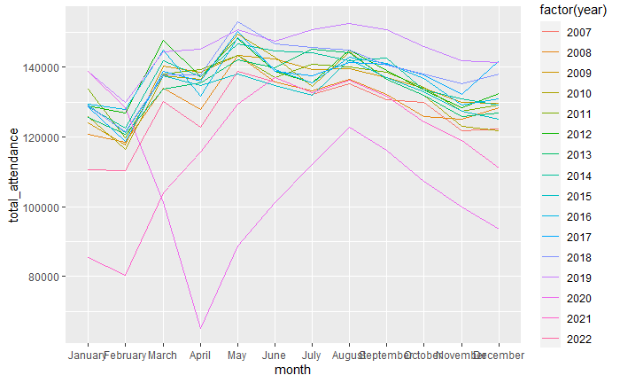

```r
# attendances - all data covid seasonal analysis
waiting_times %>%
  group_by(year, month) %>%
  summarise(total_attendance = sum(total_attendance)) %>%
  ggplot(aes(x = month, y = total_attendance, group = year, col = factor(year))) +
  geom_line()
```

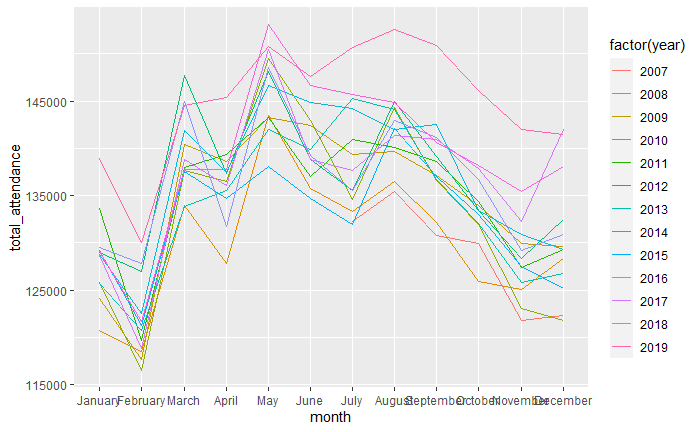

```r
# attendances per month - pre-covid seasonal analysis
waiting_times %>%
  filter(year < 2020) %>%
  group_by(year, month) %>%
  summarise(total_attendance = sum(total_attendance)) %>%
  ggplot(aes(x = month, y = total_attendance, group = year, col = factor(year))) +
  geom_line()
```

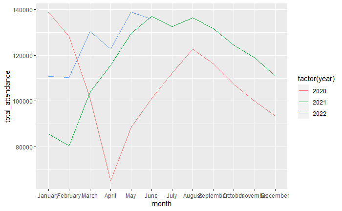

```r
# attendances per month - covid seasonal analysis
waiting_times %>%
  filter(year >= 2020) %>%
  group_by(year, month) %>%
  summarise(total_attendance = sum(total_attendance)) %>%
  ggplot(aes(x = month, y = total_attendance, group = year, col = factor(year))) +
  geom_line()
```

# How do wait times change per year? (in terms of numbers)

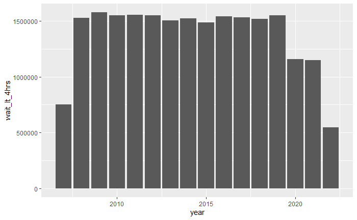

```r
# wait times less than 4 hours
waiting_times %>%
  group_by(year) %>%
  summarise(wait_lt_4hrs = sum(wait_lt_4hrs)) %>%
  ggplot(aes(x = year, y = wait_lt_4hrs)) +
  geom_col()
```

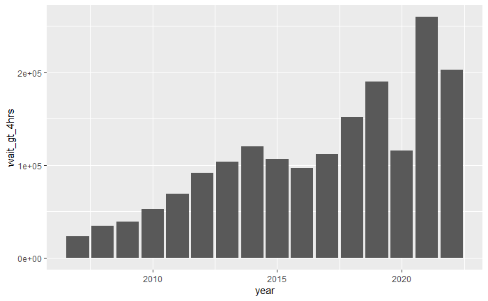

```r
# wait times more than 4 hours
waiting_times %>%
  group_by(year) %>%
  summarise(wait_gt_4hrs = sum(wait_gt_4hrs)) %>%
  ggplot(aes(x = year, y = wait_gt_4hrs)) +
  geom_col()
```

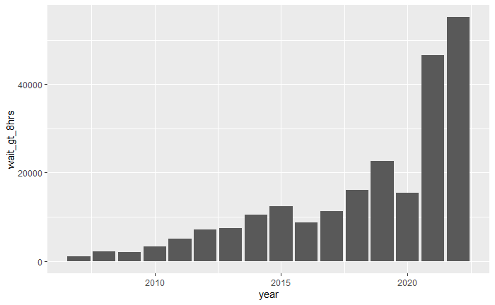

```r
# wait times more than 8 hours
waiting_times %>%
  group_by(year) %>%
  summarise(wait_gt_8hrs = sum(wait_gt_8hrs)) %>%
  ggplot(aes(x = year, y = wait_gt_8hrs)) +
  geom_col()
```

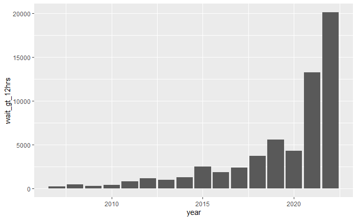

```r
# wait times more than 12 hours
waiting_times %>%
  group_by(year) %>%
  summarise(wait_gt_12hrs = sum(wait_gt_12hrs)) %>%
  ggplot(aes(x = year, y = wait_gt_12hrs)) +
  geom_col()
```

# How do wait times change per year? (in terms of proportion)

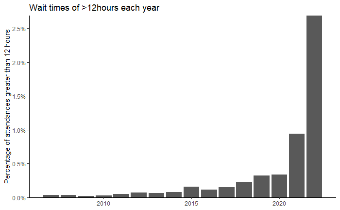

# How do wait times differ between departments? (in terms of proportions)

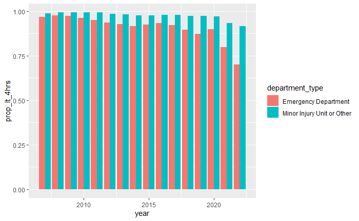

```r
# wait times less than 4 hours
waiting_times %>%
  group_by(year, department_type) %>%
  summarise(total_attendance = sum(total_attendance),
            wait_lt_4hrs = sum(wait_lt_4hrs),
            prop_lt_4hrs = wait_lt_4hrs / total_attendance) %>%
  ggplot(aes(x = year, y = prop_lt_4hrs, fill = department_type)) +
  geom_col(position = "dodge")
```

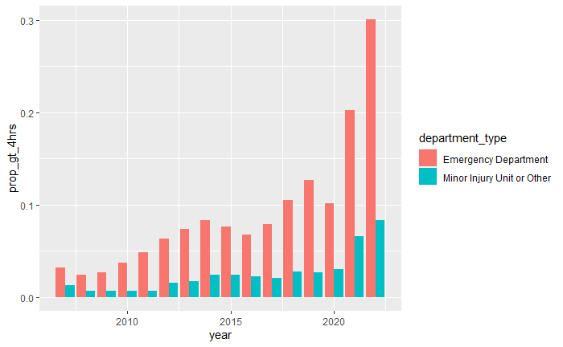

```r
# wait times more than 4 hours
waiting_times %>%
  group_by(year, department_type) %>%
  summarise(total_attendance = sum(total_attendance),
            wait_gt_4hrs = sum(wait_gt_4hrs),
            prop_gt_4hrs = wait_gt_4hrs / total_attendance) %>%
  ggplot(aes(x = year, y = prop_gt_4hrs, fill = department_type)) +
  geom_col(position = "dodge")
```

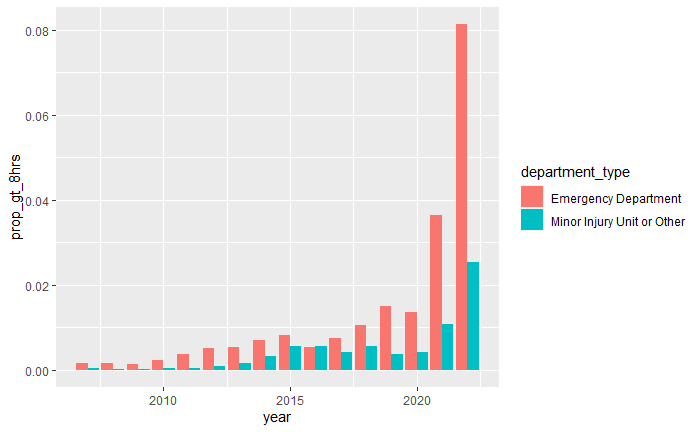

```r
# wait times more than 8 hours
waiting_times %>%
  group_by(year, department_type) %>%
  summarise(total_attendance = sum(total_attendance),
            wait_gt_8hrs = sum(wait_gt_8hrs),
            prop_gt_8hrs = wait_gt_8hrs / total_attendance) %>%
  ggplot(aes(x = year, y = prop_gt_8hrs, fill = department_type)) +
  geom_col(position = "dodge")
```

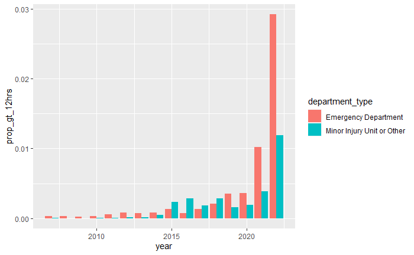

```r
# wait times more than 12 hours
waiting_times %>%
  group_by(year, department_type) %>%
  summarise(total_attendance = sum(total_attendance),
            wait_gt_12hrs = sum(wait_gt_12hrs),
            prop_gt_12hrs = wait_gt_12hrs / total_attendance) %>%
  ggplot(aes(x = year, y = prop_gt_12hrs, fill = department_type)) +
  geom_col(position = "dodge")
```

# How do wait times change per year & month? (in terms of numbers)

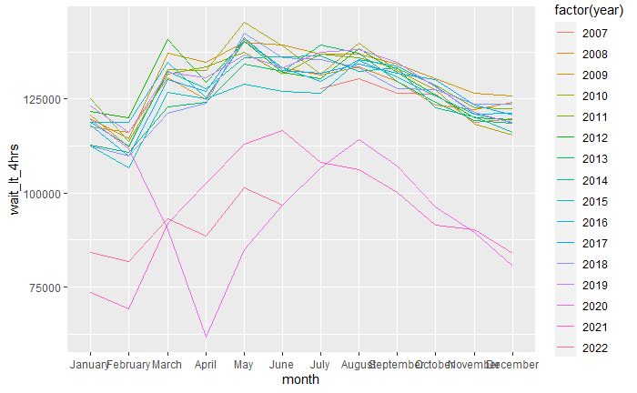

```r
# wait times less than 4 hours
waiting_times %>%
  group_by(year, month) %>%
  summarise(wait_lt_4hrs = sum(wait_lt_4hrs)) %>%
  ggplot(aes(x = month, y = wait_lt_4hrs, group = year, col = factor(year))) +
  geom_line()
```

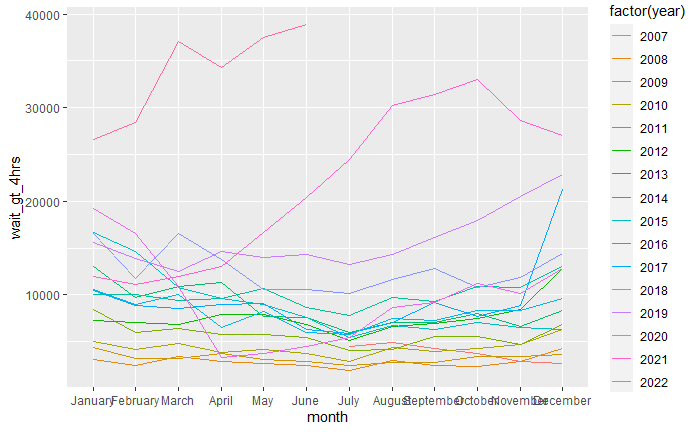

```r
# wait times more than 4 hours
waiting_times %>%
  group_by(year, month) %>%
  summarise(wait_gt_4hrs = sum(wait_gt_4hrs)) %>%
  ggplot(aes(x = month, y = wait_gt_4hrs, group = year, col = factor(year))) +
  geom_line()
```

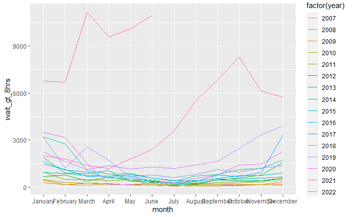

```r
# wait times more than 8 hours
waiting_times %>%
  group_by(year, month) %>%
  summarise(wait_gt_8hrs = sum(wait_gt_8hrs)) %>%
  ggplot(aes(x = month, y = wait_gt_8hrs, group = year, col = factor(year))) +
  geom_line()
```

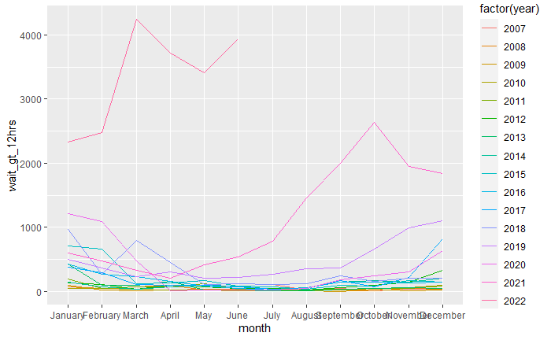

```r
# wait times more than 12 hours
waiting_times %>%
  group_by(year, month) %>%
  summarise(wait_gt_12hrs = sum(wait_gt_12hrs)) %>%
  ggplot(aes(x = month, y = wait_gt_12hrs, group = year, col = factor(year))) +
  geom_line()
```

# How do wait times vary across health boards?

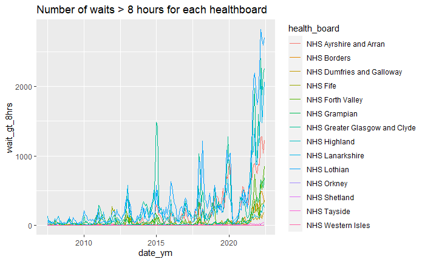

```r
# in terms of numbers
waiting_times %>%
  group_by(date_ym, health_board) %>%
  summarise(wait_gt_8hrs = sum(wait_gt_8hrs)) %>%
  ggplot(aes(x = date_ym, y = wait_gt_8hrs, col = health_board)) +
  geom_line() +
  labs(title = "Number of waits > 8 hours for each healthboard")
```

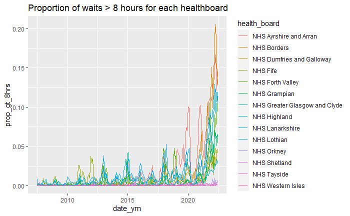

```r
# in terms of proportion
waiting_times_prop %>%
  group_by(date_ym, health_board) %>%
  summarise(prop_gt_8hrs = sum(total_attendance * prop_gt_8hrs)/
              sum(total_attendance)) %>%
  ggplot(aes(x = date_ym, y = prop_gt_8hrs, col = health_board)) +
  geom_line() +
  labs(title = "Proportion of waits > 8 hours for each healthboard")
```

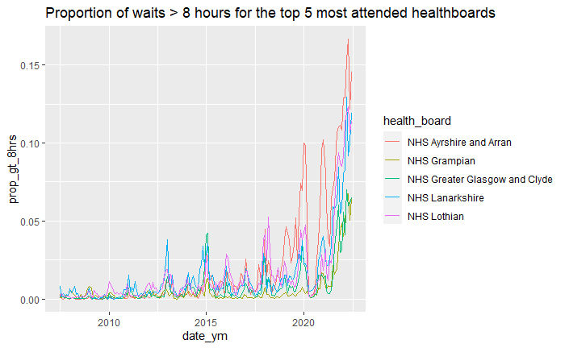

```r
# find top 5 healthboards (in terms of attendances)
top_5_attendances_by_hb <- waiting_times_prop %>%
  group_by(health_board) %>%
  summarise(total_att = sum(total_attendance)) %>%
  slice_max(total_att, n = 5)

# find bottom 5 healthboards (in terms of attendances)
bottom_5_attendances_by_hb <- waiting_times_prop %>%
  group_by(health_board) %>%
  summarise(total_att = sum(total_attendance)) %>%
  slice_min(total_att, n = 5)

# wait times across the top 5 healthboards > 8 hours
waiting_times_prop %>%
  filter(health_board %in% top_5_attendances_by_hb$health_board) %>%
  group_by(date_ym, health_board) %>%
  summarise(prop_gt_8hrs = sum(total_attendance * prop_gt_8hrs)/
              sum(total_attendance)) %>%
  ggplot(aes(x = date_ym, y = prop_gt_8hrs, col = health_board)) +
  geom_line() +
  labs(title = "Proportion of waits > 8 hours for the top 5 most attended healthboards")
```

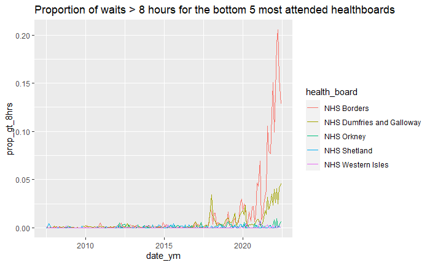

```r
# wait times across the bottom 5 healthboards > 8 hours
waiting_times_prop %>%
  filter(health_board %in% bottom_5_attendances_by_hb$health_board) %>%
  group_by(date_ym, health_board) %>%
  summarise(prop_gt_8hrs = sum(total_attendance * prop_gt_8hrs)/
              sum(total_attendance)) %>%
  ggplot(aes(x = date_ym, y = prop_gt_8hrs, col = health_board)) +
  geom_line() +
  labs(title = "Proportion of waits > 8 hours for the bottom 5 most attended healthboards")
```

[figure not shown]

```r
# wait times across the top 5 healthboards > 12 hours
waiting_times_prop %>%
  filter(health_board %in% top_5_attendances_by_hb$health_board) %>%
  group_by(date_ym, health_board) %>%
  summarise(prop_gt_12hrs = sum(total_attendance * prop_gt_12hrs)/
              sum(total_attendance)) %>%
  ggplot(aes(x = date_ym, y = prop_gt_12hrs, col = health_board)) +
  geom_line() +
  labs(title = "Proportion of waits > 12 hours for the bottom 5 most attended healthboards")
```

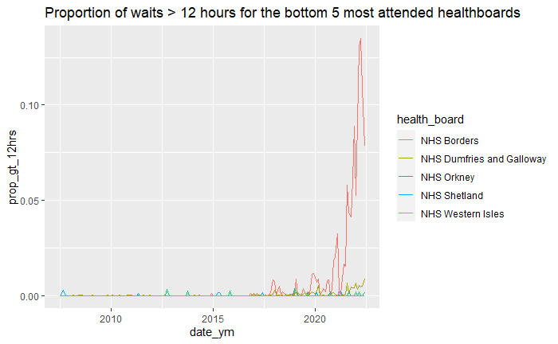

```r
# wait times across the bottom 5 healthboards > 12 hours
waiting_times_prop %>%
  filter(health_board %in% bottom_5_attendances_by_hb$health_board) %>%
  group_by(date_ym, health_board) %>%
  summarise(prop_gt_12hrs = sum(total_attendance * prop_gt_12hrs)/
              sum(total_attendance)) %>%
  ggplot(aes(x = date_ym, y = prop_gt_12hrs, col = health_board)) +
  geom_line() +
  labs(title = "Proportion of waits > 12 hours for the bottom 5 most attended healthboards")
```

[figure not shown]

```r
# wait times across each hospital in the Borders healthboard
waiting_times_prop %>%
  # filter(health_board == "NHS Borders") %>%
  group_by(date_ym, hospital_name) %>%
  summarise(prop_gt_8hrs = sum(total_attendance * prop_gt_8hrs)/
              sum(total_attendance)) %>%
  ggplot(aes(x = date_ym, y = prop_gt_8hrs, col = hospital_name)) +
  geom_line() +
  labs(title = "Proportion of waits > 8 hours for the bottom 5 most attended healthboards") +
  theme(legend.position = "none")
```

# most affected healthboards

```r
# in terms of proportion
top_5_hospital_props <- waiting_times_prop %>%
  group_by(hospital_name) %>%
  summarise(max_prop = max(prop_gt_12hrs)) %>%
  arrange(desc(max_prop)) %>%
  slice_max(max_prop, n = 5)

# in terms of numbers
waiting_times %>%
  group_by(hospital_name) %>%
  summarise(max_prop = max(wait_gt_12hrs)) %>%
  arrange(desc(max_prop))
```

| hospital_name | max_prop |
| --- | --- |
| Royal Infirmary of Edinburgh at Little France | 1064 |
| University Hospital Crosshouse | 502 |
| University Hospital Wishaw | 389 |
| Borders General Hospital | 332 |
| Queen Elizabeth University Hospital | 319 |
| University Hospital Ayr | 315 |
| Western General Hospital | 290 |
| Royal Alexandra Hospital | 257 |
| Forth Valley Royal Hospital | 243 |
| St John's Hospital | 219 |

[output cut: 83 more lines]

```r
NA
```

[figure not shown]

```r
# wait times across each hospital in the Borders healthboard
waiting_times_prop %>%
  filter(hospital_name %in% top_5_hospital_props$hospital_name) %>%
  group_by(date_ym, hospital_name) %>%
  summarise(prop_gt_12hrs = sum(total_attendance * prop_gt_12hrs)/
              sum(total_attendance)) %>%
  ggplot(aes(x = date_ym, y = prop_gt_12hrs, col = hospital_name)) +
  geom_line() +
  labs(title = "Proportion of waits > 8 hours for the bottom 5 most attended healthboards")
```

## For the years 2007 to 2019, provide a summary of the effects of wait times at different times of the year.

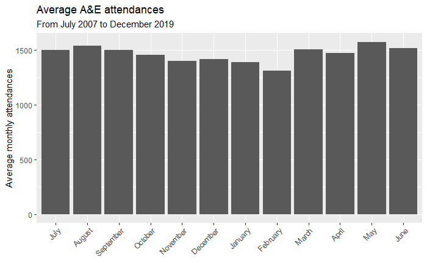

```r
waiting_times_summary <- waiting_times_prop %>%
  filter(year <= 2019) %>%
  mutate(month = factor(month, levels = c("July", "August", "September", "October", "November", "December", "January", "February", "March", "April", "May", "June"))) %>%
  group_by(month) %>%
  summarise(total_attends = mean(total_attendance),
            prop_lt_4hrs = sum(total_attendance * prop_lt_4hrs)/ sum(total_attendance),
            prop_gt_4hrs = sum(total_attendance * prop_gt_4hrs)/ sum(total_attendance),
            prop_gt_8hrs = sum(total_attendance * prop_gt_8hrs)/ sum(total_attendance),
            prop_gt_12hrs = sum(total_attendance * prop_gt_12hrs)/ sum(total_attendance))

waiting_times_summary %>%
  ggplot(aes(x = month, y = total_attends)) +
  geom_col() +
  theme(axis.text.x = element_text(angle = 45, hjust = 1),
        axis.title.x = element_blank()) +
  labs(y = "Average monthly attendances",
       title = "Average A&E attendances",
       subtitle = "From July 2007 to December 2019 ") +
  geom_smooth()
```

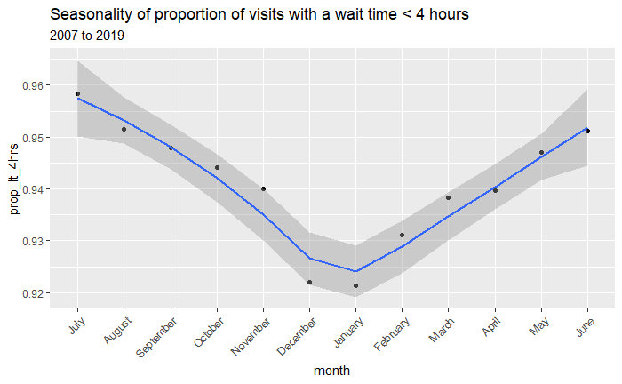

```r
waiting_times_summary %>%
  ggplot(aes(x = month, y = prop_lt_4hrs, group = 1)) +
  geom_point() +
  labs(title = "Seasonality of proportion of visits with a wait time < 4 hours",
         subtitle = "2007 to 2019") +
  theme(axis.text.x = element_text(angle = 45, hjust = 1)) +
  geom_smooth()
```

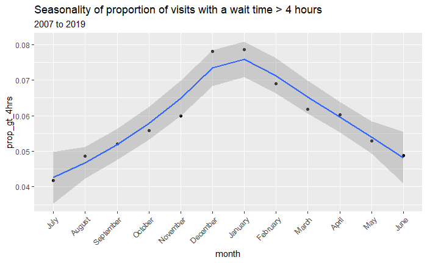

```r
waiting_times_summary %>%
  ggplot(aes(x = month, y = prop_gt_4hrs, group = 1)) +
  geom_point() +
    labs(title = "Seasonality of proportion of visits with a wait time > 4 hours",
         subtitle = "2007 to 2019") +
  theme(axis.text.x = element_text(angle = 45, hjust = 1)) +
  geom_smooth()
```